# Learning Word Embeddings from Vector Space Models

This article describes how to learn word embeddings from vector space models.

Ali Zaidi https://github.com/akzaidi (Microsoft AI and Research)

Let’s walk through an example of learning word embeddings from vector space models. We’ll take a look at the GloVe model.

## GloVe - Global Vectors

```r
library(tidyverse)
data_dir <- "~/tatk/resources/data/imdb/aclImdb/train"
unlabeled_df <- tibble(file_name = list.files(file.path(data_dir, "unsup"),
                                              full.names = TRUE))
unlabeled_df <- unlabeled_df %>%
  mutate(review = map(file_name, ~read_lines(.x)))
```

### Preprocess Data

We need to get the data pre-processed, which can mean a number of things:

- case normalization
- regex
- punctuation / numeric removal
- stop-word removal
- phrase-detection
- part-of-speech tagging
- normalization: stemming / lemmatization
- tokenization

For now, we’ll just case-normalization.

```r
library(text2vec)
preprocessor_fn <- tolower
tokenizer_fn <- word_tokenizer

preprocessed_df <- unlabeled_df %>%
  select(review) %>%
  mutate(preprocessed_review = preprocessor_fn(review), tokenized_review = tokenizer_fn(preprocessed_review))
```

### Distribution of Review Length

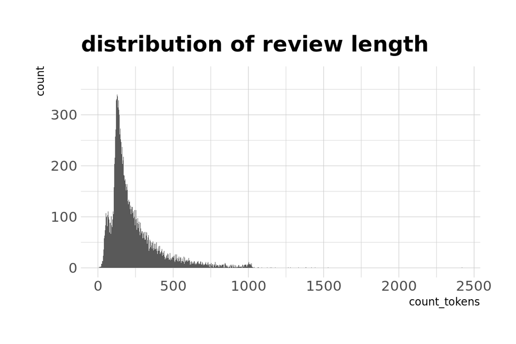

```r
preprocessed_df %>%
  mutate(count_tokens = map_int(tokenized_review, ~length(.x))) %>%
  ggplot(aes(x = count_tokens)) +
  geom_histogram(binwidth = 1) + theme_ipsum_rc() +
  labs(title = "distribution of review length")
```

### Create Vocabulary from Tokens

```r
tokens <- itoken(preprocessed_df$tokenized_review, progressbar = TRUE)
vocab <- create_vocabulary(tokens) %>% prune_vocabulary(term_count_min = 5L)
vectorizer <- vocab_vectorizer(vocab)
term_co_occur <- create_tcm(tokens, vectorizer, skip_grams_window=5L)
```

### Fit GloVe Model

We have our term co-occurrence matrix, so now we just need to train our model.

```r
glove_model <- GlobalVectors$new(word_vectors_size = 200,
                                 vocabulary = vocab,
                                 x_max = 10)
imdb_vectors <- glove_model$fit_transform(term_co_occur, n_iter = 10, convergence_tol = 0.01)
```

```
INFO [2018-05-19 16:18:49] 2018-05-19 16:18:49 - epoch 1, expected cost 0.1069
INFO [2018-05-19 16:18:53] 2018-05-19 16:18:53 - epoch 2, expected cost 0.0582
INFO [2018-05-19 16:18:57] 2018-05-19 16:18:57 - epoch 3, expected cost 0.0470
INFO [2018-05-19 16:19:01] 2018-05-19 16:19:01 - epoch 4, expected cost 0.0374
INFO [2018-05-19 16:19:05] 2018-05-19 16:19:05 - epoch 5, expected cost 0.0336
INFO [2018-05-19 16:19:09] 2018-05-19 16:19:09 - epoch 6, expected cost 0.0309
INFO [2018-05-19 16:19:13] 2018-05-19 16:19:13 - epoch 7, expected cost 0.0289
INFO [2018-05-19 16:19:17] 2018-05-19 16:19:17 - epoch 8, expected cost 0.0273
INFO [2018-05-19 16:19:21] 2018-05-19 16:19:21 - epoch 9, expected cost 0.0260
INFO [2018-05-19 16:19:25] 2018-05-19 16:19:25 - epoch 10, expected cost 0.0248
```

```r
imdb_vectors %>% dim
```

```
[1] 42320   200
```

Note that model learns two sets of word vectors - main and context. Essentially they are the same since model is symmetric. From our experience learning two sets of word vectors leads to higher quality embeddings. GloVe model is “decomposition” model (inherits from mlapiDecomposition - generic class of models which decompose input matrix into two low-rank matrices). So on par with any other mlapiDecomposition model second low-rank matrix (context word vectors) is available in components field.

Common practice to take the sum of the context embeddings and main embeddings:

```r
imdb_embedding <- imdb_vectors + t(glove_model$components)
```

### Save and Visualize with TensorBoard

```r
imdb_embedding_df <- imdb_embedding %>% as.data.frame()

write_delim(imdb_embedding_df, path = file.path(data_dir, "imdb_embeddings.tsv"), col_names = FALSE, delim = "\t")

write_delim(as.data.frame(row.names(imdb_embedding_df)), path = file.path(data_dir, "imdb_embeddings_metadata.tsv"), col_names = FALSE, delim = "\t")
```

## Intrinsic Tests

```r
analogy_test <- function(embeddings, vec1, vec2, vec3,
                         top_n = 5, method = "cosine", norm = "l2") {

  vec4 <-  embeddings[vec1, , drop = FALSE] -
  embeddings[vec2, , drop = FALSE] +
  embeddings[vec3, , drop = FALSE]
  similarity <- sim2(x = embeddings, y = vec4,
                     method = method, norm = norm)
  head(sort(similarity[,1], decreasing = TRUE), top_n)

}

analogy_test(imdb_embedding, "king", "man", "woman")
```

```
     king     queen    arthur      kong    france
0.7543552 0.4005499 0.3980408 0.3969077 0.3878910
```

```r
analogy_test(imdb_embedding, "good", "great", "bad")
```

```
      bad      good    pretty      just    either
0.9095738 0.7100873 0.6461499 0.6370537 0.6327118
```

```r
analogy_test(imdb_embedding, "horror", "scary", "comedy")
```

```
   comedy    horror     genre     drama   classic
0.8309321 0.7322498 0.6518901 0.6121166 0.6119986
```

## Extrinsic Evaluation

Let’s evaluate this on an extrinsic test: sentiment analysis. We’ll use a labeled corpus of reviews:

```r
read_directory <- function(directory, sub_directories,
                           sample_perc = 0.1) {

  files <- map2(rep(directory, length(sub_directories)),
                    sub_directories, file.path) %>%
    map(~list.files(.x, full.names = TRUE))
  names(files) <- sub_directories
  files <- bind_rows(files) %>% gather(key = "sentiment", value = "path")

  files %>%
    sample_frac(sample_perc) %>%
    mutate(review = map(path, ~read_lines(.x))) %>% unnest(review)

}

labeled_df <- read_directory(data_dir, c("pos", "neg"))
```

### Featurize reviews:

```r
featurize_reviews <- function(labeled_data,
                              embedding = imdb_embedding,
                              aggregation_fn = colSums) {

  lookup <- function(words) {
    words <- words[words %in% row.names(embedding)]
    embedding[words, , drop = FALSE]
  }

  labeled_data <- labeled_data %>%
    mutate(sep_words = map(review, ~unlist(str_split(.x, " ")[[1]]))) %>%
    mutate(embedding_matrix = map(sep_words, ~lookup(unlist(.x))),
           features = map(embedding_matrix, ~aggregation_fn(.x)))

  labeled_data %>% select(sentiment, features) %>%
    mutate(features = map(features, ~as_tibble(t(.x)))) %>% unnest(features)


}

labeled_df <- featurize_reviews(labeled_df)
```

### Learning Curves

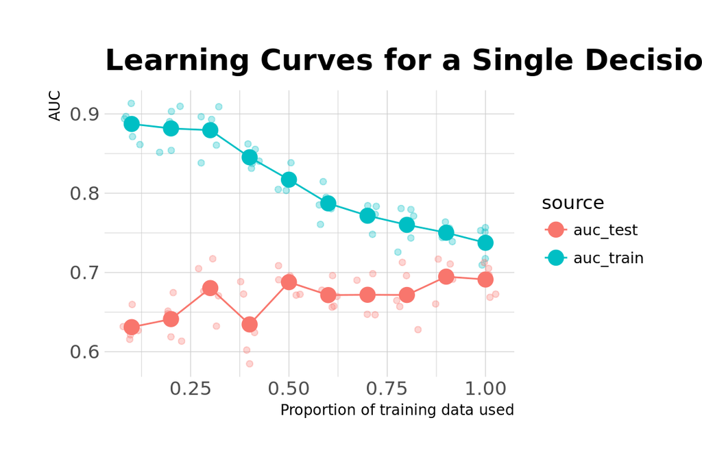

```r
library(pipelearner)


learning_curves <- labeled_df %>% pipelearner() %>%
  learn_cvpairs(crossv_mc, n = 5, test = .15) %>%
  learn_curves(seq(.1, 1, by = .1)) %>%
  learn_models(rpart, sentiment ~ .) %>%
  learn()

response_var <- function(model) {
  formula(model)[[2L]]
}

response <- function(model, data) {
  eval(response_var(model), as.data.frame(data))
}

calc_auc <- function(model, test_data) {

  library(pROC)
  prediction <- predict(model, test_data)
  actual    <- response(model, test_data)
  roc_value <- roc(actual, prediction[,2])
  auc(roc_value)
}


results <- learning_curves %>%
  mutate(
    auc_train = map2_dbl(fit, train, calc_auc),
    auc_test  = map2_dbl(fit, test,  calc_auc)
  )


results %>%
  select(train_p, contains("auc")) %>%
  gather(source, auc, contains("auc")) %>%
  ggplot(aes(train_p, auc, color = source)) +
   geom_jitter(width = .03, alpha = .3) +
   stat_summary(geom = "line", fun.y = mean) +
   stat_summary(geom = "point", fun.y = mean, size = 4) +
   labs(x = "Proportion of training data used",
        y = "AUC",
        title = "Learning Curves for a Single Decision Tree") +
  theme_ipsum_rc()
```